# training-requirements: RNA Seq Analysis

This document describes the steps of an RNA Seq analysis.

Based on the workshop performed in [Week 8 of BigBioinformatics R Programming and RNA-Seq Analysis](https://www.bigbioinformatics.org/r-and-rnaseq-analysis).

## Scope

In this analysis, we want to know what effects knocking down the [EWSR1-FLI1 oncogene](https://en.wikipedia.org/wiki/EWS/FLI) will have on the transcriptome of Ewing sarcoma tumor cells.

## Data

We’ll first start by reading in our counts stored as a `RangedSummarizedExperiment` object.

```r
rse <- readRDS("EwS.rds")
```

Checking our sample metadata, we have two sample conditions: A EF1 knockdown and our control.

```r
cd <- as.data.frame(
  SummarizedExperiment::colData(rse)
)
testit::assert("condition" %in% colnames(cd))
testit::assert(unique(cd$condition) == c("shCTR", "shEF1"))
```

### Condition

We’ll now construct our `DESeqDataSet` separating our data by the column `condition`.

- Splits our dataset between between our controls and the EF1 knockdown samples.

```r
deseq_dataset <- DESeq2::DESeqDataSet(rse, design = ~condition)
```

### QC

Next, we check whether our data showns any sign of batch effects.

This is accomplished by:

1. Log transforming the counts.
   - Use `rlog` to convert counts to regularized log scale for visualization.
   - PCA results based on features with highest variance.
     - On linear scale, high mean features dominate.
     - On log scale. small changes with low counts would dominate

       ```
       A gene with 2 reads == 200% more reads than a gene with 1 reads
       A gene with 101 reads == 1% more reads than a gene with 100 reads.
       ```

2. Performing PCA on the log transformed matrix of counts.

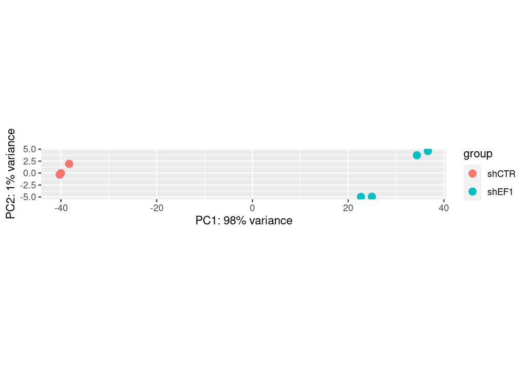

```r
pca <- DESeq2::rlog(deseq_dataset) %>% BiocGenerics::plotPCA()
pca
```

From this plot, we can see that the first PC (PC1) cleanly splits samples by our sample conditions.

- Because of this we know that the conditions explain the most variance.
- This gives us good confidence that any changes we observe in our analysis are due to our conditions rather than any technical variation.

## Analysis

We perform the differential expression analysis using [`DESeq2`](http://bioconductor.org/packages/devel/bioc/vignettes/DESeq2/inst/doc/DESeq2.html).

And get our results showing relative change in expression of the knockdown compared to the control.

- `contrast` is a chr vector where 2nd and 3rd args are the numerator and denominator.

```r
dds <- DESeq2::DESeq(deseq_dataset)
res <- DESeq2::results(dds, contrast = c("condition", "shEF1", "shCTR"))
```

### MA Plot

Next, we plot an MA plot.

- This shows the log2 fold changes attributable to a given variable over the mean of normalized counts for all the samples in the DESeqDataSet.<sup>3</sup>
- Answers question: > How does fold change relate to how much gene is expressed.

First, we have to shrink the fold change of low count genes as shifts in variance can be extreme.

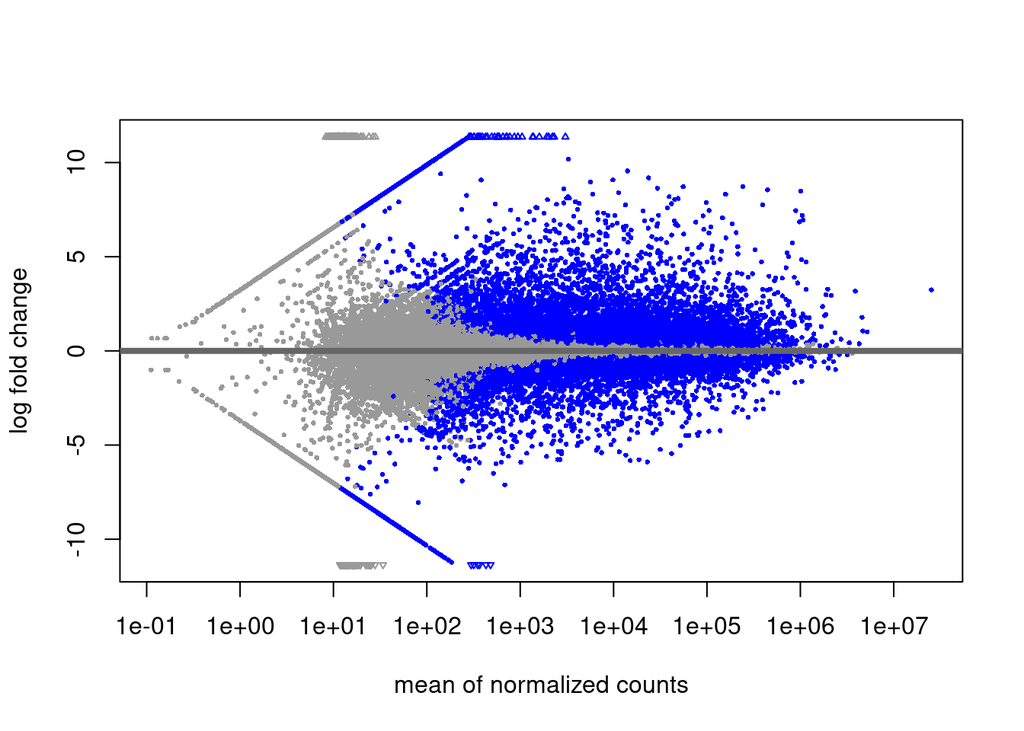

Spurious Log Fold Changes at Low Count Genes

```r
plot_ma_origfc <- DESeq2::plotMA(res)
```

```r
plot_ma_origfc
```

By shrinking the fold change: <sup>4</sup>

- Creates prior distribution of lfcs from genes with high counts.
- Filters noise from low count genes.

```r
# coef = 2 is the second item of resultsNames(dds)
res_shrunkfc <- DESeq2::lfcShrink(
  dds = dds,
  res = res,
  type = "normal",
  coef = 2
)
```

After lfc shrinkage, the points with spurious fold changes are moved toward the center.

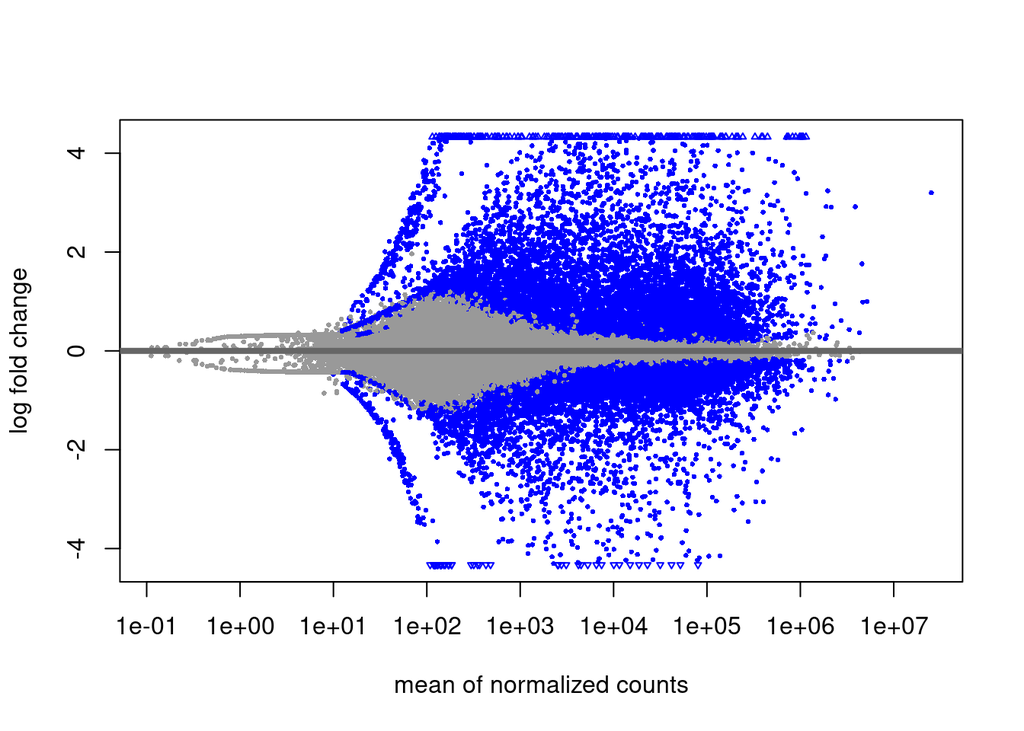

Adjusted Log Fold Change

```r
plot_ma_shrunkfc <- DESeq2::plotMA(res_shrunkfc)
```

```r
plot_ma_shrunkfc
```

### Annotation

Next will annotate our data. Currently, it lists genes with their ENSMBL IDs which isn’t helpful.

```
r$> head(res_shrunkfc)
log2 fold change (MAP): condition shEF1 vs shCTR
Wald test p-value: condition shEF1 vs shCTR
DataFrame with 6 rows and 6 columns
                     baseMean log2FoldChange     lfcSE      stat      pvalue        padj
                    <numeric>      <numeric> <numeric> <numeric>   <numeric>   <numeric>
ENSG00000000003.14 32363.1500     -0.6338445 0.1584261 -4.000851 0.000063115 0.000256938
ENSG00000000005.5      0.0000             NA        NA        NA          NA          NA
ENSG00000000419.12 48118.6436     -0.1795122 0.0834463 -2.151229 0.031458107 0.070859811
ENSG00000000457.13 15337.8714     -0.0609588 0.1335490 -0.456452 0.648065053 0.783818379
ENSG00000000460.16 23463.4429     -0.7325704 0.1939355 -3.777309 0.000158532 0.000604503
ENSG00000000938.12    13.5656     -0.4378801 0.4032424 -2.053576 0.040016781 0.086639736
```

We’ll wrap our data wrangling operations in `annotate_deseq_res` where the following is performed:

1. Use the `AnnotationDbi` package to run a query on `EnsDB.Hsapiens.v86` and pull gene symbols mapping to Ensmbl IDs.
2. Pull each id to a new column `ENSID`
3. Clean the id removing trailing digits and set it a new `GENEID` column
4. Drop `ENSID`.
5. Perform an inner join only labeling genes by `GENEID`s that exist in both dataframes.

```r
# Annotate deseq gene IDs with symbols.
annotate_deseq_res <- function(resdf) {
  ens2sym <- AnnotationDbi::select(
    EnsDb.Hsapiens.v86::EnsDb.Hsapiens.v86,
    keys = AnnotationDbi::keys(EnsDb.Hsapiens.v86::EnsDb.Hsapiens.v86),
    columns = c("SYMBOL")
  )

  return(
    # nolint start
    resdf %>%
      tibble::rownames_to_column(var = "ENSID") %>%
      # Remove any trailing digits from IDs. ex. ########.##
      dplyr::mutate(GENEID = gsub(ENSID, pattern = "\\..+", replacement = "")) %>%
      dplyr::select(-ENSID) %>%
      dplyr::inner_join(y = ens2sym, by = "GENEID")
    # nolint end
  )
}
```

The output is saved as `resdf`.

```r
resdf <- as.data.frame(res_shrunkfc) %>% annotate_deseq_res()
```

## Results

### Volcano Plot

To get an overview of our differentially expressed genes, we’ll plot a volcano plot.

- Volcano plots allow visualization of genes that have large fold changes (either upregulated or downregulated) that are significant.

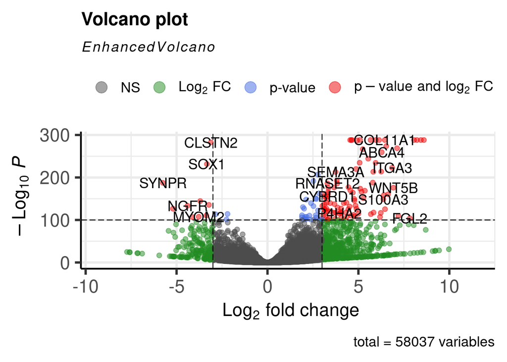

Significant Differentially Expressed Genes

```r
plot_volcano <- EnhancedVolcano::EnhancedVolcano(
  resdf,
  lab = resdf$SYMBOL,
  pCutoff = 1e-100,
  FCcutoff = 3,
  x = "log2FoldChange", y = "padj"
)
plot_volcano
```

### Top DE Genes

To get the top differentially expressed genes, we must first declare some cutoffs for valid genes.

- Has a **p-value of ±0.01** to be considered significant.
- Has a **log fold change of ±2** to be considered overexpressed or underexpressed, respectively.

```r
n_genes <- 10
p_thr <- 0.01
log_fold_change_thr <- 2
```

This code segment:

1. Filter our DE genes by p-value threshold of 0.01
2. Assigns a new column `type` describing the expression level of the gene.
3. Sorts, in descending order, by `log2FoldChange`.
4. Adds a `rank` column.

```r
resdf_de_genes <- resdf %>%
  # Must be significant.
  dplyr::filter(padj < p_thr) %>%
  # Add column to describe expression level.
  dplyr::mutate(
    type = dplyr::case_when(
      log2FoldChange > log_fold_change_thr ~ "overexpressed",
      log2FoldChange < -log_fold_change_thr ~ "underexpressed",
      .default = "other"
    )
  ) %>%
  # Sort by log2 fold change.
  dplyr::arrange(desc(log2FoldChange)) %>%
  # And add a rank.
  dplyr::mutate(rank = row_number())
```

After wrangling and sorting the dataset, we can simply filter by `rank` to get the top 10 DE genes.

```r
num_de_genes <- nrow(resdf_de_genes)
resdf_top_de_genes <- resdf_de_genes %>%
  dplyr::filter(
    between(rank, 1, n_genes) |
    between(rank, num_de_genes - (n_genes - 1), num_de_genes)
  )
```

Top 10 Differentially Expressed Genes

| baseMean | log2FoldChange | lfcSE | stat | pvalue | padj | GENEID | SYMBOL | type | rank |
| --- | --- | --- | --- | --- | --- | --- | --- | --- | --- |
| 3047.0584 | 9.974751 | 0.4516531 | 12.052841 | 0 | 0 | ENSG00000260892 | CTD-2026K11.1 | overexpressed | 1 |
| 1923.8258 | 9.435970 | 0.4589825 | 11.510632 | 0 | 0 | ENSG00000121068 | TBX2 | overexpressed | 2 |
| 2015.0510 | 9.229471 | 0.4717779 | 11.393305 | 0 | 0 | ENSG00000260139 | CSPG4P13 | overexpressed | 3 |
| 1382.6563 | 9.216214 | 0.4550030 | 11.238251 | 0 | 0 | ENSG00000282304 | RP11-1223D19.3 | overexpressed | 4 |
| 1357.8088 | 9.080876 | 0.4619501 | 11.135469 | 0 | 0 | ENSG00000250072 | CTC-529P8.1 | overexpressed | 5 |
| 3287.6123 | 8.701940 | 0.4061981 | 18.904534 | 0 | 0 | ENSG00000188064 | WNT7B | overexpressed | 6 |
| 241845.2962 | 8.599187 | 0.1512808 | 56.804611 | 0 | 0 | ENSG00000111341 | MGP | overexpressed | 7 |
| 865.9660 | 8.572619 | 0.4690547 | 10.615289 | 0 | 0 | ENSG00000148600 | CDHR1 | overexpressed | 8 |
| 444947.3461 | 8.434800 | 0.1451556 | 58.092947 | 0 | 0 | ENSG00000146674 | IGFBP3 | overexpressed | 9 |
| 945.6396 | 8.433092 | 0.4811077 | 10.549066 | 0 | 0 | ENSG00000204941 | PSG5 | overexpressed | 10 |
| 157.2910 | -5.376232 | 0.6013693 | -8.257609 | 0 | 0 | ENSG00000230403 | LINC01066 | underexpressed | 11270 |
| 2519.7541 | -5.442170 | 0.2915744 | -18.610179 | 0 | 0 | ENSG00000145681 | HAPLN1 | underexpressed | 11271 |
| 23045.2035 | -5.754897 | 0.1950822 | -29.486585 | 0 | 0 | ENSG00000163630 | SYNPR | underexpressed | 11272 |
| 184.5467 | -5.954303 | 0.5849079 | -8.810225 | 0 | 0 | ENSG00000211965 | IGHV3-49 | underexpressed | 11273 |
| 318.0202 | -6.893666 | 0.5604153 | -9.858309 | 0 | 0 | ENSG00000157502 | MUM1L1 | underexpressed | 11274 |
| 349.8534 | -7.127465 | 0.5526808 | -10.106520 | 0 | 0 | ENSG00000198765 | SYCP1 | underexpressed | 11275 |
| 298.1019 | -7.163953 | 0.5447584 | -10.099176 | 0 | 0 | ENSG00000238185 | RP11-252M21.6 | underexpressed | 11276 |
| 367.3476 | -7.574800 | 0.5310199 | -10.562108 | 0 | 0 | ENSG00000159224 | GIP | underexpressed | 11277 |
| 481.2470 | -7.579984 | 0.5421848 | -10.629236 | 0 | 0 | ENSG00000138722 | MMRN1 | underexpressed | 11278 |
| 430.0231 | -7.725648 | 0.5297031 | -10.746470 | 0 | 0 | ENSG00000214553 | LRRC37A11P | underexpressed | 11279 |

### Sources

1. https://www.bigbioinformatics.org/r-and-rnaseq-analysis
2. https://en.wikipedia.org/wiki/EWS/FLI
3. http://bioconductor.org/packages/devel/bioc/vignettes/DESeq2/inst/doc/DESeq2.html
4. https://www.biostars.org/p/445113/
5. https://support.bioconductor.org/p/77461/#77466
6. https://training.galaxyproject.org/training-material/topics/transcriptomics/tutorials/rna-seq-viz-with-volcanoplot/tutorial.html